# mimic_heart

Sharon Lee

5/13/2020

Exploration and Modeling of a MIMIC III Cohort: Looking at premature heart attack (65 years and younger) and factors in order to predict outcome (mortality).

#read in our dataset

```r
setwd('C:/USFMSHI/HS 614/MIMIC')
heart <- read.csv("data_heartattack_final1.csv", header = T)
```

EDA

```r
summary(heart)
```

```
##        X             hadm_id         subject_id
##  Min.   :   1.0   Min.   :100161   Min.   :   24
##  1st Qu.: 459.5   1st Qu.:125048   1st Qu.:10411
##  Median : 918.0   Median :150090   Median :21447
##  Mean   : 918.0   Mean   :150732   Mean   :30124
##  3rd Qu.:1376.5   3rd Qu.:177120   3rd Qu.:43938
##  Max.   :1835.0   Max.   :199993   Max.   :99830
##
##                   ethnicity    gender                         diagnosis
##  WHITE                 :1208   F: 503   CHEST PAIN                 : 138
##  UNKNOWN/NOT SPECIFIED : 318   M:1332   CORONARY ARTERY DISEASE    : 103
##  BLACK/AFRICAN AMERICAN: 102            MYOCARDIAL INFARCTION      :  69
##  UNABLE TO OBTAIN      :  47            ACUTE CORONARY SYNDROME    :  68
##  OTHER                 :  39            ACUTE MYOCARDIAL INFARCTION:  62
##  HISPANIC OR LATINO    :  37            (Other)                    :1394
##  (Other)               :  84            NA's                       :   1
##                 discharge_location  expire_flag          age
##  HOME                    :832      Min.   :0.0000   Min.   : 0.00
##  HOME HEALTH CARE        :553      1st Qu.:0.0000   1st Qu.:50.41
##  DEAD/EXPIRED            :141      Median :0.0000   Median :56.98
##  REHAB/DISTINCT PART HOSP:137      Mean   :0.2866   Mean   :54.95
##  SNF                     : 79      3rd Qu.:1.0000   3rd Qu.:61.16
##  LONG TERM CARE HOSPITAL : 37      Max.   :1.0000   Max.   :65.00
##  (Other)                 : 56
##    icd9_list       height          weight           iculos
##  41071  :843   Min.   : 66.0   Min.   : 40.00   Min.   : 0.0456
##  41041  :250   1st Qu.:168.0   1st Qu.: 75.00   1st Qu.: 1.2820
##  41011  :241   Median :173.0   Median : 87.00   Median : 2.2118
##  41091  :108   Mean   :171.9   Mean   : 89.27   Mean   : 4.2704
##  41031  : 68   3rd Qu.:178.0   3rd Qu.:100.00   3rd Qu.: 4.4089
##  41001  : 66   Max.   :196.0   Max.   :240.00   Max.   :76.9211
##  (Other):259   NA's   :1456    NA's   :1293     NA's   :4
##  total_cholesterol hdl_cholesterol ldl_cholesterol  triglycerides
##  157    : 16       42     : 41     Min.   :  6.00   73     : 13
##  177    : 14       41     : 39     1st Qu.: 69.00   96     : 12
##  201    : 14       40     : 37     Median : 94.00   121    : 11
##  137    : 13       33     : 30     Mean   : 98.09   87     : 11
##  143    : 13       44     : 30     3rd Qu.:122.00   140    : 10
##  (Other):804       (Other):681     Max.   :481.00   (Other):843
##  NA's   :961       NA's   :977     NA's   :1018     NA's   :935
```

[output cut: 9 more lines]

```
##  NotDone:390   5.6    :  56   99     : 58   Min.   : 64.00
##  9      :108   5.7    :  51   98     : 47   1st Qu.: 91.00
##  8      : 96   5.5    :  47   97     : 45   Median : 97.00
##  7      : 87   5.9    :  39   96     : 36   Mean   : 94.18
##  5      : 57   5.8    :  38   94     : 34   3rd Qu.: 99.00
##  (Other):903   (Other): 434   (Other):743   Max.   :114.00
##  NA's   :194   NA's   :1170   NA's   :872   NA's   :1546
##           heart_rhythm   heart_rate     max_resp_rate         procedure_codes
##  Sinus Tachy    :628   Min.   : 66.00   Min.   : 6.00   3893          :  12
##  Normal Sinus   :314   1st Qu.: 91.00   1st Qu.:35.00   9671          :  10
##  Sinus Brady    :203   Median : 98.00   Median :35.00   3613,3961,3615:   6
##  Vent. Tachy    : 33   Mean   : 94.37   Mean   :35.39   3615,3613,3961:   6
##  Supravent Tachy: 25   3rd Qu.: 99.00   3rd Qu.:40.00   3722,8856     :   6
##  (Other)        : 49   Max.   :149.00   Max.   :65.00   (Other)       :1753
##  NA's           :583   NA's   :1293     NA's   :1293    NA's          :  42
```

#in total, we have 1835 patients in this dataset #drop X #icd9_list #drop height (1456 NAs) #drop weight (1293 NAs) #drop total_cholesterol (961 NAs) #drop hdl_cholesterol (977 NAs) #drop ldl_cholesterol (1018 NAs) #drop triglycerides (935 NAs) #drop crp (1757 NAs)  
#drop hba1c (1170 NAs) #drop mean_bp (1546 NAs) #drop heart_rate (1293 NAs)  
#drop max_resp_rate (1293 NAs)  
#drop procedure_codes

```r
heart <- heart[ , -c(1, 10, 11, 12, 14, 15, 16, 17, 20, 23, 25, 27, 28, 29)]

#we don't need hadm_id, subject_id, diagnosis, discharge location as well
heart <- heart[ , -c(1, 2, 5, 6)]
summary(heart)
```

```
##                   ethnicity    gender    expire_flag          age
##  WHITE                 :1208   F: 503   Min.   :0.0000   Min.   : 0.00
##  UNKNOWN/NOT SPECIFIED : 318   M:1332   1st Qu.:0.0000   1st Qu.:50.41
##  BLACK/AFRICAN AMERICAN: 102            Median :0.0000   Median :56.98
##  UNABLE TO OBTAIN      :  47            Mean   :0.2866   Mean   :54.95
##  OTHER                 :  39            3rd Qu.:1.0000   3rd Qu.:61.16
##  HISPANIC OR LATINO    :  37            Max.   :1.0000   Max.   :65.00
##  (Other)               :  84
##      iculos        red_blood_cells       hb        creatinine_kinase
##  Min.   : 0.0456   4.34   :  22    Min.   : 3.50   94     :  25
##  1st Qu.: 1.2820   4.41   :  19    1st Qu.: 9.30   91     :  19
##  Median : 2.2118   4.50   :  18    Median : 9.90   93     :  18
##  Mean   : 4.2704   3.75   :  17    Mean   :11.06   99     :  17
##  3rd Qu.: 4.4089   3.92   :  17    3rd Qu.:13.30   97     :  16
##  Max.   :76.9211   (Other):1719    Max.   :20.10   (Other):1557
##  NA's   :4         NA's   :  23    NA's   :747     NA's   : 183
##   ck_isoenzyme    glucose             heart_rhythm
##  NotDone:390   99     : 58   Sinus Tachy    :628
##  9      :108   98     : 47   Normal Sinus   :314
##  8      : 96   97     : 45   Sinus Brady    :203
##  7      : 87   96     : 36   Vent. Tachy    : 33
##  5      : 57   94     : 34   Supravent Tachy: 25
##  (Other):903   (Other):743   (Other)        : 49
##  NA's   :194   NA's   :872   NA's           :583
```

```r
heart <- heart[-which(rowSums(is.na(heart)) >= 3),]
```

#ethnicity

```r
summary(heart$ethnicity)  #there are 24 ethnicity types in this dataset
```

```
##                                     ASIAN
##                                        15
##                      ASIAN - ASIAN INDIAN
##                                         2
##                         ASIAN - CAMBODIAN
##                                         0
##                           ASIAN - CHINESE
##                                         3
##                        ASIAN - VIETNAMESE
##                                         0
##                    BLACK/AFRICAN AMERICAN
##                                        84
##                        BLACK/CAPE VERDEAN
##                                         1
##                             BLACK/HAITIAN
##                                         1
##                        HISPANIC OR LATINO
##                                        32
##                   HISPANIC/LATINO - CUBAN
##                                         2
##              HISPANIC/LATINO - GUATEMALAN
##                                         0
##            HISPANIC/LATINO - PUERTO RICAN
##                                         4
##                            MIDDLE EASTERN
##                                         1
##                      MULTI RACE ETHNICITY
##                                         5
## NATIVE HAWAIIAN OR OTHER PACIFIC ISLANDER
##                                         0
##                                     OTHER
##                                        27
##                PATIENT DECLINED TO ANSWER
##                                        16
##                                PORTUGUESE
##                                         1
##                          UNABLE TO OBTAIN
##                                        35
##                     UNKNOWN/NOT SPECIFIED
##                                       290
##                                     WHITE
##                                       998
##                         WHITE - BRAZILIAN
##                                         1
##                    WHITE - OTHER EUROPEAN
##                                         2
##                           WHITE - RUSSIAN
##                                         2
```

```r
#regroup ethnicity types: asian, black, hispanic, white, others
lev_e <- c("ASIAN", "BLACK", "HISPANIC", "WHITE", "OTHERS")
heart$ethnicities <- factor(rep(NA, nrow(heart)), order = F, levels = lev_e)
heart$ethnicities[heart$ethnicity == "PATIENT DECLINED TO ANSWER" |
                  heart$ethnicity == "UNABLE TO OBTAIN"|
                  heart$ethnicity == "UNKNOWN/NOT SPECIFIED"] <- NA
heart$ethnicities[heart$ethnicity == "ASIAN"|
                  heart$ethnicity == "ASIAN - ASIAN INDIAN" |
                  heart$ethnicity == "ASIAN - CAMBODIAN" |
                  heart$ethnicity == "ASIAN - CHINESE" |
                  heart$ethnicity == "ASIAN - VIETNAMESE"] <- "ASIAN"

heart$ethnicities[heart$ethnicity == "BLACK/AFRICAN AMERICAN"|
                    heart$ethnicity == "BLACK/CAPE VERDEAN" |
                    heart$ethnicity == "BLACK/HAITIAN"] <- "BLACK"

heart$ethnicities[heart$ethnicity == "HISPANIC/LATINO - CUBAN" |
                    heart$ethnicity == "HISPANIC OR LATINO" |
                    heart$ethnicity == "HISPANIC/LATINO - CUBAN"] <- "HISPANIC"

heart$ethnicities[heart$ethnicity == "PORTUGUESE" |
                    heart$ethnicity == "WHITE" |
                    heart$ethnicity == "WHITE - BRAZILIAN" |
                    heart$ethnicity == "WHITE - OTHER EUROPEAN" |
                    heart$ethnicity == "WHITE - RUSSIAN"] <- "WHITE"

heart$ethnicities[heart$ethnicity == "MIDDLE EASTERN" |
                    heart$ethnicity == "MULTI RACE ETHNICITY" |
                    heart$ethnicity == "NATIVE HAWAIIAN OR OTHER PACIFIC ISLANDER" |
                    heart$ethnicity == "OTHER"] <- "OTHERS"
```

```r
#make sure new factor has the correct count for each level
summary(heart$ethnicities) #345NAs
```

```
##    ASIAN    BLACK HISPANIC    WHITE   OTHERS     NA's
##       20       86       34     1004       33      345
```

```r
#remove ethniity column
heart <- heart[ ,-1]
#remove rows with NAs
heart <- heart[-which(is.na(heart$ethnicities)),]
```

#expire_flag

```r
#change to factor
class(heart$expire_flag) #right now is int
```

```
## [1] "integer"
```

```r
heart$expire_flag <- as.factor(heart$expire_flag)
levels(heart$expire_flag) <- c("no", "yes")
summary(heart$expire_flag) #make sure there are no NAs
```

```
##  no yes
## 792 385
```

#age

```r
summary(heart$age) #we want premature heart attack, making sure maximum age is 65
```

```
##    Min. 1st Qu.  Median    Mean 3rd Qu.    Max.
##   18.69   50.85   56.95   55.08   61.22   65.00
```

#iculos (in fractional days)

```r
summary(heart$iculos)
```

```
##    Min. 1st Qu.  Median    Mean 3rd Qu.    Max.    NA's
##  0.1219  1.4021  2.5769  4.7774  4.8918 76.9211       2
```

```r
#2NA's
heart[which(is.na(heart$iculos)), ]
```

```
##      gender expire_flag   age iculos red_blood_cells   hb creatinine_kinase
## 693       M         yes 62.11     NA            4.05 11.2                59
## 1254      M         yes 58.71     NA            3.93 11.5               241
##      ck_isoenzyme glucose heart_rhythm ethnicities
## 693             9     261         <NA>       WHITE
## 1254            9     483         <NA>       WHITE
```

```r
#impute with mean
icu_mean <- mean(heart$iculos, na.rm = TRUE)
heart$iculos[is.na(heart$iculos)] <- icu_mean
```

#red_blood_cells

```r
class(heart$red_blood_cells) #factor right now, change to numeric
```

```
## [1] "factor"
```

```r
heart$red_blood_cells[heart$red_blood_cells == 'UNABLE TO REPORT'] <- NA
heart$red_blood_cells[heart$red_blood_cells == 'UNABLE TO REPORT DUE MCHC >38.0'] <- NA
heart$red_blood_cells <- as.numeric(as.character(heart$red_blood_cells))
summary(heart$red_blood_cells)
```

```
##    Min. 1st Qu.  Median    Mean 3rd Qu.    Max.    NA's
##   1.960   3.940   4.350   4.377   4.800   6.720       2
```

```r
heart[which(is.na(heart$red_blood_cells)), ] #impute with mean
```

```
##     gender expire_flag   age iculos red_blood_cells   hb creatinine_kinase
## 310      M          no 46.08 2.0504              NA  9.9               888
## 742      M         yes 54.25 5.2044              NA 11.3                96
##     ck_isoenzyme glucose heart_rhythm ethnicities
## 310           46      90  Sinus Tachy       WHITE
## 742            7      85  Sinus Tachy       BLACK
```

```r
rbc_mean <- mean(heart$red_blood_cells, na.rm = TRUE)
heart$red_blood_cells[is.na(heart$red_blood_cells)] <- rbc_mean
summary(heart$red_blood_cells)
```

```
##    Min. 1st Qu.  Median    Mean 3rd Qu.    Max.
##   1.960   3.940   4.350   4.377   4.800   6.720
```

#hb

```r
summary(heart$hb)  #371 NAs
```

```
##    Min. 1st Qu.  Median    Mean 3rd Qu.    Max.    NA's
##   3.500   9.325   9.900  11.070  13.100  20.100     371
```

```r
#drop hb column
heart <- heart[,-6]
```

#creatinine kinase need to be changed to numeric

```r
heart$creatinine_kinase[heart$creatinine_kinase == "ERROR"] <- NA
heart$creatinine_kinase <- as.numeric(as.character(heart$creatinine_kinase))
summary(heart$creatinine_kinase)  #66 NAs, min at 8 and max at 96400
```

```
##    Min. 1st Qu.  Median    Mean 3rd Qu.    Max.    NA's
##     8.0    91.0   402.0  1193.1   855.5 96400.0      66
```

```r
heart[which(is.na(heart$creatinine_kinase)),]
```

```
##      gender expire_flag   age  iculos red_blood_cells creatinine_kinase
## 7         M          no 48.44  3.9181            4.49                NA
## 12        F          no 56.59  3.2327            4.39                NA
## 123       M          no 54.24  5.6847            3.52                NA
## 128       M          no 46.97  8.0175            3.85                NA
## 150       F          no 38.42  1.1214            3.63                NA
## 188       F         yes 62.89  3.0815            3.93                NA
## 190       F          no 55.65  1.7697            4.46                NA
## 240       M          no 38.49  1.5000            5.38                NA
## 246       M          no 60.71 16.0503            4.30                NA
## 250       M          no 38.52  1.0780            3.30                NA
## 271       F         yes 62.89 15.9748            4.18                NA
## 281       M          no 55.01  0.9878            4.06                NA
## 284       F          no 55.75  4.2674            4.27                NA
## 306       M          no 48.25  1.8487            4.61                NA
```

[output cut: 119 more lines]

```r
#impute with median
kinase_median <- median(heart$creatinine_kinase, na.rm = TRUE)
heart$creatinine_kinase[is.na(heart$creatinine_kinase)] <- kinase_median
```

#ck_isoenzyme

```r
heart$ck_isoenzyme  #NA, NotDone,Greater than 500
```

```
##    [1] 6                NotDone          4                <NA>
##    [5] 65               3                <NA>             78
##    [9] 57               6                NotDone          9
##   [13] NotDone          4                2                99
##   [17] 9                7                304              6
##   [21] 81               2                5                70
##   [25] 848              338              NotDone          NotDone
##   [29] NotDone          NotDone          NotDone          NotDone
##   [33] NotDone          64               55               92
##   [37] 7                57               484              20
##   [41] NotDone          97               NotDone          NotDone
##   [45] 64               7                47               8
##   [49] 7                70               13               NotDone
##   [53] 56               27               2                67
##   [57] 9                17               NotDone          9
```

[output cut: 281 more lines]

```r
heart$ck_isoenzyme[heart$ck_isoenzyme == 'NotDone'] <- NA
#substitue greater than 500 to NA
heart$ck_isoenzyme[heart$ck_isoenzyme == "GREATER THAN 500"] <- NA
#change to numeric
heart$ck_isoenzyme <- as.numeric(as.character(heart$ck_isoenzyme))
summary(heart$ck_isoenzyme)  #411 NAs
```

```
##    Min. 1st Qu.  Median    Mean 3rd Qu.    Max.    NA's
##    1.00    7.00   22.50   60.58   74.00  970.00     411
```

```r
heart <- heart[,-7]
```

#glucose

```r
summary(heart$glucose)  #more than 445 NAs
```

```
##               99               97               98               94
##               46               36               33               27
##               96               95               93               91
##               27               26               20               17
##               92              146               84               90
##               16               10               10               10
##               89               87               88              135
##                9                8                8                7
##               82               85              139              140
##                7                7                6                6
##              214              118              124              158
##                6                5                5                5
##               80               86              117              122
##                5                5                4                4
##              129              130              136              138
```

[output cut: 35 more lines]

```r
#drop glucose
heart <- heart[,-7]
```

#heart rhythm

```r
summary(heart$heart_rhythm)  #236 NAs
```

```
## 1st Deg AV Block          A Paced       Atrial Fib   Atrial Flutter
##                0                0                3                2
##         AV Paced Comp Heart Block       Junctional     Normal Sinus
##                0                0                0              215
##    Other/Remarks      Sinus Brady      Sinus Tachy  Supravent Tachy
##                0              150              498               21
##          V Paced      Vent. Tachy  Ventricular Fib             NA's
##               19               26                7              236
```

```r
heart$heart_rhythm <- droplevels(heart$heart_rhythm)

#remove rows with NA
heart <- heart[-which(is.na(heart$heart_rhythm)), ]
```

#data cleaning complete

```r
summary(heart)
```

```
##  gender  expire_flag      age            iculos        red_blood_cells
##  F:279   no :622     Min.   :18.69   Min.   : 0.1219   Min.   :1.960
##  M:662   yes:319     1st Qu.:50.37   1st Qu.: 1.3832   1st Qu.:3.970
##                      Median :56.59   Median : 2.3834   Median :4.380
##                      Mean   :54.87   Mean   : 4.5268   Mean   :4.392
##                      3rd Qu.:61.06   3rd Qu.: 4.6544   3rd Qu.:4.810
##                      Max.   :65.00   Max.   :76.9211   Max.   :6.510
##
##  creatinine_kinase          heart_rhythm   ethnicities
##  Min.   :    8     Sinus Tachy    :498   ASIAN   : 10
##  1st Qu.:   93     Normal Sinus   :215   BLACK   : 61
##  Median :  402     Sinus Brady    :150   HISPANIC: 23
##  Mean   : 1240     Vent. Tachy    : 26   WHITE   :823
##  3rd Qu.:  853     Supravent Tachy: 21   OTHERS  : 24
##  Max.   :96400     V Paced        : 19
##                    (Other)        : 12
```

correlations #create new dataframe that holds only numeric variables

```r
heart_num <- heart[, -c(1, 2, 7, 8)]

#change all factor variables to numeric
heart_num$gender <- as.numeric(heart$gender)
heart_num$expire_flag <- as.numeric(heart$expire_flag)
heart_num$heart_rhythm <- as.numeric(heart$heart_rhythm)
heart_num$ethnicities <- as.numeric(heart$ethnicities)

#use spearman method when calculate correlation since our dataframe now has ranks
heart_cor <- cor(heart_num, use = "pairwise.complete.obs", method = "spearman")
heart_cor
```

```
##                           age      iculos red_blood_cells creatinine_kinase
## age                1.00000000  0.08021715    -0.159024067       -0.16147344
## iculos             0.08021715  1.00000000    -0.102709898       -0.13649138
## red_blood_cells   -0.15902407 -0.10270990     1.000000000        0.17324541
## creatinine_kinase -0.16147344 -0.13649138     0.173245414        1.00000000
## gender             0.01548706 -0.15449356     0.241081832        0.19167769
## expire_flag        0.08709847  0.25803487    -0.165522412       -0.25688884
## heart_rhythm       0.01012513  0.42324698    -0.010088809       -0.07413273
## ethnicities        0.08593799 -0.01376968     0.009990725        0.02774446
##                        gender expire_flag heart_rhythm  ethnicities
## age                0.01548706  0.08709847   0.01012513  0.085937994
## iculos            -0.15449356  0.25803487   0.42324698 -0.013769685
## red_blood_cells    0.24108183 -0.16552241  -0.01008881  0.009990725
## creatinine_kinase  0.19167769 -0.25688884  -0.07413273  0.027744457
## gender             1.00000000 -0.17901626  -0.10692337  0.103487783
## expire_flag       -0.17901626  1.00000000   0.20014201 -0.029540550
## heart_rhythm      -0.10692337  0.20014201   1.00000000 -0.056861514
## ethnicities        0.10348778 -0.02954055  -0.05686151  1.000000000
```

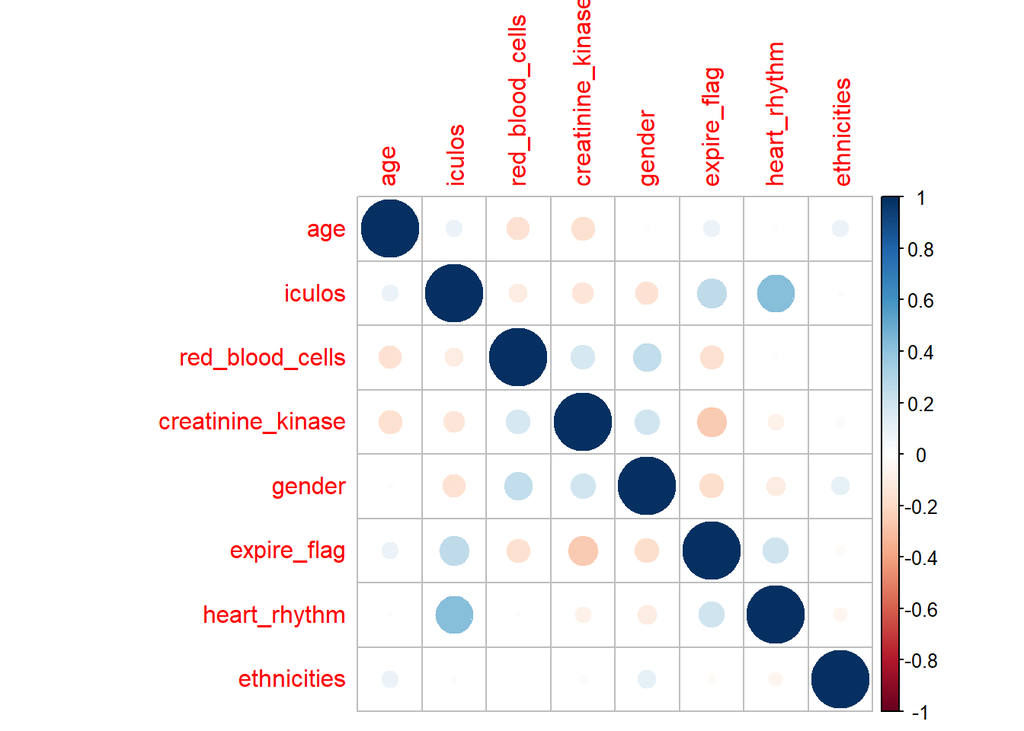

```r
corrplot(heart_cor)
```

Data Visualizations

#ethnicities

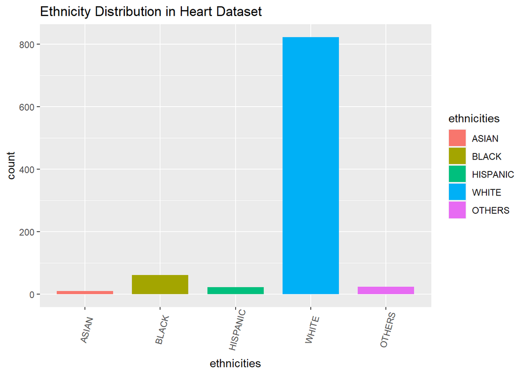

```r
g1 <- ggplot(heart, aes(ethnicities))
g1 + geom_bar(aes(fill = ethnicities), width = 0.75) +
  theme(axis.text.x = element_text(angle = 75, vjust=0.6)) +
  labs(title = "Ethnicity Distribution in Heart Dataset")
```

#gender

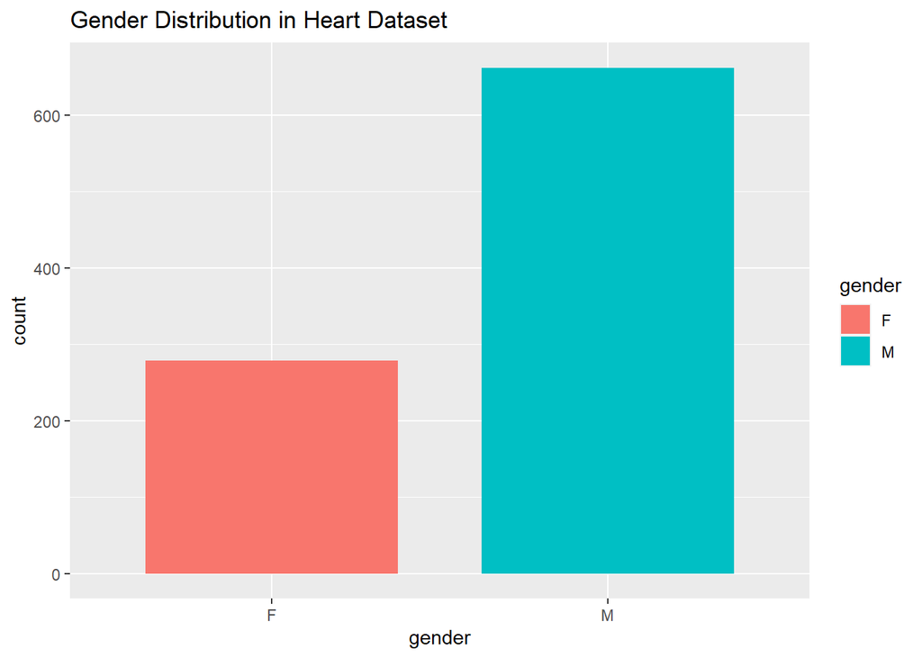

```r
g2 <- ggplot(heart, aes(gender))
g2 + geom_bar(aes(fill = gender), width = 0.75)  +
  labs(title="Gender Distribution in Heart Dataset")
```

#expire flag

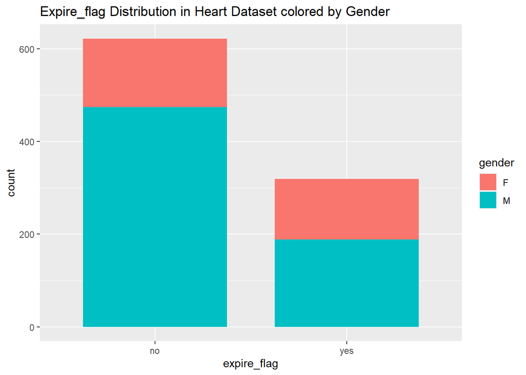

```r
g3 <- ggplot(heart, aes(expire_flag))
g3 + geom_bar(aes(fill = gender), width = 0.75)  +
  labs(title="Expire_flag Distribution in Heart Dataset colored by Gender")
```

#age

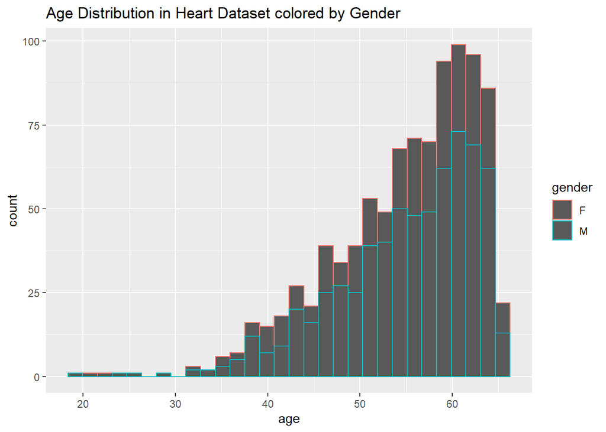

```r
g4 <- ggplot(heart, aes(age))
g4 + geom_histogram(aes(col = gender), bins = 30) +
  labs(title="Age Distribution in Heart Dataset colored by Gender")
```

#iculos